# DataWranglingPython

Python

```python
import pandas as pd
import numpy as np
import seaborn as sns
import matplotlib.pyplot as plt
from IPython.display import Image
```

**Project Goals**

The goals of our project is to see if there is a correlation between various factors that allow for Best Picture wins to occur. Currently, there is a belief that Oscar Bait exists, which are specific factors that movies follow that increases the chances of winning Oscars.This may include movie run times, movie genres, and the season the movie was released. We want to see if this idea has truth to it and discover if other factors such as critique and audience reviews can impact Oscar wins too.

**About the Data Source**

**Kaggle:** This dataset includes data starting from 1927 to 2020 that includes Oscar Nominees and Winners for Best Picture. It also includes the genre of each movie and their IMDB and Rotten Tomatoes rating. The grain of this table is Film.

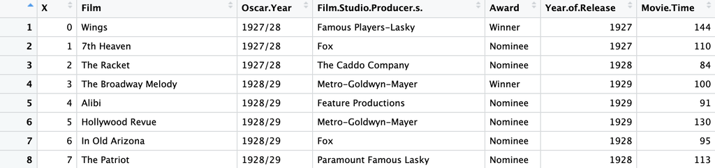

```python
Image("/Users/ansh/Downloads/oscar_df_screenshot.png")
```

```python
oscar_df1 = pd.read_csv("/Users/ansh/Desktop/Data Wrangling Final Project/oscars_df1.csv")
```

**Dataful:** This dataset includes data starting from the beginning of the Oscars in 1928 to 2024 that includes all categories of nominations and winners for Oscar nominated movies. The grain of this table is Film.

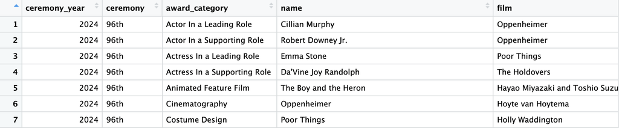

```python
Image("/Users/ansh/Downloads/oscar_df2_screenshot.png")
```

```python
oscar_df2 = pd.read_csv("/Users/ansh/Desktop/Data Wrangling Final Project/oscars_df2.csv")
```

**IMDB:** Contains basic details from movies on IMDB, including primary title and isAdults. The grain of this table is primaryTitle and titleType.

We used `low_memory=False` because, without it, pandas reads the file in chunks, which sometimes leads to inconsistent data types in a column. By loading the entire file at once, it ensures the data types are consistent and avoids errors caused by mixed data.

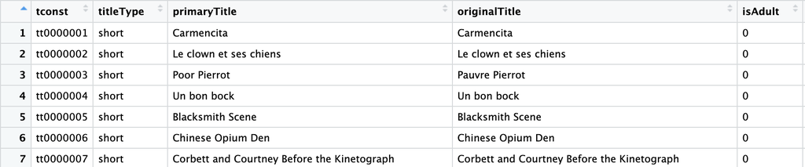

```python
Image("/Users/ansh/Downloads/oscar_df3_screenshot.png")
```

```python
oscar_df3 = pd.read_csv("/Users/ansh/Desktop/Data Wrangling Final Project/oscars_df3.csv", low_memory = False)
```

```python
oscar_df101 = (
    oscar_df1
    .loc[:, [
        "Film",
        "Film Studio/Producer(s)",
        "Award",
        "Year of Release",
        "Movie Time",
        "Movie Genre",
        "IMDB Rating",
        "IMDB Votes",
        "Critic Consensus",
        "Audience Rating",
        "Audience Count"
    ]]
)

oscar_df101.columns = (
    oscar_df101.columns
    .str.replace(' ', '_')  # Replace spaces with underscores
    .str.replace('/', '_')  # Replace slashes with underscores
    .str.replace('(', '')   # Remove opening parentheses
    .str.replace(')', '')   # Remove closing parentheses
    .str.lower()            # Convert column names to lowercase
)
```

Renaming columns with spaces to underscores for consistency. After some critiques, we changed the movie_time(mins) to movie_time_mins to reduce the confusion for column names. Displaying a glimpse of the renamed dataset

```python
oscar_df102 = oscar_df101.rename(columns={
    "film_studio_producers": "producer_name",
    "year_of_release": "year",
    "movie_time": "movie_time_mins"
})

oscar_df102.info()
```

```
<class 'pandas.core.frame.DataFrame'>
RangeIndex: 571 entries, 0 to 570
Data columns (total 11 columns):
 #   Column            Non-Null Count  Dtype
---  ------            --------------  -----
 0   film              571 non-null    object
 1   producer_name     571 non-null    object
 2   award             571 non-null    object
 3   year              571 non-null    int64
 4   movie_time_mins   571 non-null    int64
 5   movie_genre       571 non-null    object
 6   imdb_rating       571 non-null    float64
 7   imdb_votes        571 non-null    object
 8   critic_consensus  339 non-null    object
 9   audience_rating   439 non-null    float64
 10  audience_count    439 non-null    float64
dtypes: float64(3), int64(2), object(6)
memory usage: 49.2+ KB
```

After importing the data from a CSV file into Python, we validated that all columns had the correct data types, except for the award and imdb_votes columns, which we updated to the appropriate data types.

```python
oscar_df103 = oscar_df102.copy()
oscar_df103['imdb_votes'] = oscar_df103['imdb_votes'].str.replace(",", "").astype(float)  # Removing commas and converting to numeric
oscar_df103['award'] = oscar_df103['award'].astype('category')  # Converting the award column to a categorical type
oscar_df103['join_key'] = oscar_df103['film'].str.upper()  # Creating a join key by converting film names to uppercase

oscar_df103.info()
```

```
<class 'pandas.core.frame.DataFrame'>
RangeIndex: 571 entries, 0 to 570
Data columns (total 12 columns):
 #   Column            Non-Null Count  Dtype
---  ------            --------------  -----
 0   film              571 non-null    object
 1   producer_name     571 non-null    object
 2   award             571 non-null    category
 3   year              571 non-null    int64
 4   movie_time_mins   571 non-null    int64
 5   movie_genre       571 non-null    object
 6   imdb_rating       571 non-null    float64
 7   imdb_votes        571 non-null    float64
 8   critic_consensus  339 non-null    object
 9   audience_rating   439 non-null    float64
 10  audience_count    439 non-null    float64
 11  join_key          571 non-null    object
dtypes: category(1), float64(4), int64(2), object(5)
memory usage: 49.9+ KB
```

Since oscar_df1 originally included both the movie release year and the Oscar ceremony year (e.g., 1927/28, where 1927 is the release year and 1928 is the ceremony year), while oscar_df2 only included the ceremony year, we needed to standardize the data to match the tables. To keep the process simple, we decided to use the Oscar ceremony year consistently across both datasets. This meant removing the movie release year from oscar_df1 and adjusting it so that the year matched the ceremony year in oscar_df2. To achieve this, we added 1 to the movie release year in oscar_df1 to align it with the ceremony year in oscar_df2. This ensured a clean and consistent match between the two datasets.

```python
# Adding 1 year to the 'year' column in the dataframe
oscar_df104 = oscar_df103.copy()
oscar_df104['year'] = oscar_df104['year'] + 1
```

The existing dataset categorizes movie genres in a very broad or generic manner, making it less useful for detailed analysis. To improve the granularity and relevance of the genre classification, we reclassified the genres into a set of specific, meaningful categories.

```python
# Reclassifying movie genres
oscar_df105 = oscar_df104.copy()
oscar_df105['movie_genre_1'] = np.select(
    [
        oscar_df105['movie_genre'].str.contains("Drama|History|Biography", regex=True),
        oscar_df105['movie_genre'].str.contains("Comedy|Romance|Musical|Family|Fantasy", regex=True),
        oscar_df105['movie_genre'].str.contains("Action|Adventure|Crime|Thriller|Sci-Fi", regex=True),
        oscar_df105['movie_genre'].str.contains("Crime|Thriller|Mystery|Film-Noir", regex=True),
        oscar_df105['movie_genre'].str.contains("Musical|Music", regex=True),
        oscar_df105['movie_genre'].str.contains("Sci-Fi|Fantasy", regex=True),
        oscar_df105['movie_genre'].str.contains("Family|Animation", regex=True),
    ],
    [
        "Drama",
        "Comedy",
        "Action/Adventure",
        "Crime/Thriller/Mystery",
        "Musical/Music",
        "Fantasy/Sci-Fi",
        "Family/Animation",
    ],
    default=oscar_df105['movie_genre']  # Keeping the same original genre if no match
)
```

```python
# Removing the generic genre column to avoid any confusion
# Renaming the updated movie_genre_1 column back to movie_genre

table1 = oscar_df105.drop(columns=['movie_genre']).rename(columns={'movie_genre_1': 'movie_genre'})
```

**Table2**

In Table 2 for the year 2024, the film names and actor names were placed in the incorrect columns. To resolve this, I created temporary columns and assigned the correct film and actor names to their respective columns for 2024.

```python
# Filtering for 'Best Picture' award category
oscar_df201 = oscar_df2[oscar_df2['award_category'] == 'Best Picture']

# Creating temporary columns for film and actor names
oscar_df202 = oscar_df201.copy()
oscar_df202['temp_name'] = oscar_df202['name']
oscar_df202['temp_film'] = oscar_df202['film']

# Correcting the film and actor columns for 2024
oscar_df203 = oscar_df202.copy()
oscar_df203['film'] = oscar_df203.apply(lambda row: row['temp_name'] if row['ceremony_year'] == 2024 else row['film'], axis=1)
oscar_df203['name'] = oscar_df203.apply(lambda row: row['temp_film'] if row['ceremony_year'] == 2024 else row['name'], axis=1)
oscar_df203['join_key'] = oscar_df203['film'].str.upper()  # Creating a join key based on film names

# Removing temporary columns and renaming 'ceremony_year' to 'year'
table2 = oscar_df203.drop(columns=['temp_name', 'temp_film']).rename(columns={'ceremony_year': 'year'})
```

**Table3**

We wanted to analyze whether the movie rating, such as PG-13 or ADULT, influences Oscar wins. To do this, we are retrieving the ‘isAdult’ column from our third data frame, as it’s not available in the other two tables.

In R, we received a warning about the one-to-many relationship, but in Python, no such warning was shown. After joining all three tables, I checked the relationships and verified if the films were being duplicated. It turned out that the join was indeed based on a one-to-many relationship, resulting in duplicate values for films, as shown in the snippet below. To maintain consistency across all results, I removed the duplicate values using the `drop_duplicates` function.

[figure not shown]

```python
Image("/Users/ansh/Downloads/img.png")
```

```python
# Filtering for movies and selecting distinct primary title and 'isAdult' columns
oscar_df301 = oscar_df3[oscar_df3['titleType'] == 'movie'][['primaryTitle', 'isAdult']].drop_duplicates()

# Creating a new table with a join key based on the primaryTitle
oscar_df301['join_key'] = oscar_df301['primaryTitle'].str.upper()  # Converting primaryTitle to uppercase for consistency

table3 = oscar_df301
```

**Merging Tables**

In this step, we are merging all three tables to create a unified table that will serve as the basis for our analysis.

To join the tables, we first converted the film column to uppercase in all the tables and then performed the join based on this uppercase column, as it provides better coverage for matching.

**Merging 3 tables: table1, table2, and table3 by ‘join_key’**

```python
# Performed an inner join between table1 and table2 on 'join_key'
merged_table101 = pd.merge(table1, table2, on='join_key', how='inner')

# Performed a left join between merged_table101 and table3 on 'join_key'
merged_table102 = pd.merge(merged_table101, table3, on='join_key', how='left')
```

```python
merged_table102.head()
```

|  | film_x | producer_name | award | year_x | movie_time_mins | imdb_rating | imdb_votes | critic_consensus | audience_rating | audience_count | join_key | movie_genre | year_y | ceremony | award_category | name | film_y | status | primaryTitle | isAdult |
| --- | --- | --- | --- | --- | --- | --- | --- | --- | --- | --- | --- | --- | --- | --- | --- | --- | --- | --- | --- | --- |
| 0 | All Quiet on the Western Front | Universal | Winner | 1931 | 152 | 8.1 | 59214.0 | NaN | NaN | NaN | ALL QUIET ON THE WESTERN FRONT | Drama | 2023 | 95th | Best Picture | Malte Grunert, Producer | All Quiet on the Western Front | Nominated | All Quiet on the Western Front | 0.0 |
| 1 | Little Women | RKO Radio | Nominee | 1934 | 115 | 7.2 | 6778.0 | NaN | 78.0 | 9776.0 | LITTLE WOMEN | Drama | 2020 | 92nd | Best Picture | Amy Pascal, Producer | Little Women | Nominated | Little Women | 0.0 |
| 2 | Cleopatra | Paramount | Nominee | 1935 | 100 | 6.8 | 3678.0 | NaN | NaN | NaN | CLEOPATRA | Drama | 1964 | 36th | Best Picture | Walter Wanger, Producer | Cleopatra | Nominated | Cleopatra | 0.0 |
| 3 | Mutiny on the Bounty | Metro-Goldwyn-Mayer | Winner | 1936 | 132 | 7.7 | 21805.0 | The historical inaccuracies in this high-seas ... | 83.0 | 8061.0 | MUTINY ON THE BOUNTY | Drama | 1963 | 35th | Best Picture | Aaron Rosenberg, Producer | Mutiny on the Bounty | Nominated | Mutiny on the Bounty | 0.0 |
| 4 | Les Misérables | 20th Century | Nominee | 1936 | 108 | 7.7 | 3468.0 | NaN | NaN | NaN | LES MISÉRABLES | Drama | 2013 | 85th | Best Picture | Tim Bevan, Eric Fellner, Debra Hayward and Cam... | Les Misérables | Nominated | NaN | NaN |

Selecting only one 'film' column after the join and renaming columns for consistency

```python
# Removing unwanted columns and renaming
oscar_table = merged_table102.drop(columns=['film_y', 'year_x', 'primaryTitle', 'award_category', 'name', 'status'])

# Renaming columns
oscar_table = oscar_table.rename(columns={'film_x': 'film', 'year_y': 'year'})

# Sorting by 'year' in descending order
oscar_table = oscar_table.sort_values(by='year', ascending=False)
```

Getting into the Analysis:

We plan to explore the relationship between movie genres and their likelihood of winning the Best Picture award. Additionally, we #want to examine other factors that might influence a film’s success at the Oscars, such as runtime, release season (e.g., movies #released between October and December), and potentially even other variables like budget or the presence of established talent.

Our analysis will feature visualizations to highlight trends and relationships. For instance, we want to create a stacked bar #chart to display how the characteristics of Oscar-winning films have shifted over time, from the first annual Oscars onward. #Scatterplots will be used to explore the correlation between specific genres and their frequency of winning Best Picture. These #visualizations will help us capture the evolving landscape of Oscar-winning films and the potential patterns that emerge in #genre, seasonality, and other influential factors.

By examining these trends and presenting our findings visually, we aim to better understand the nuances of Oscar-winning films #and what qualities might enhance a film’s chances of recognition.

**Movie Length(in mins) vs. Oscar Wins**

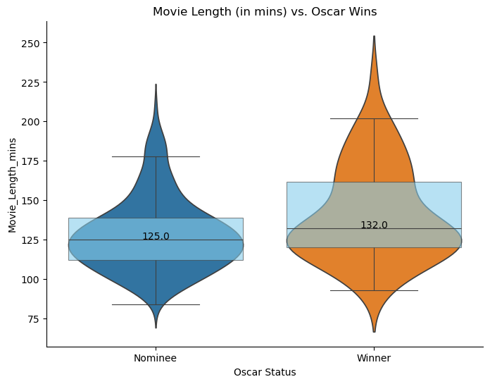

```python
# Created the violin plot with jitter for movie length by award status
plt.figure(figsize=(8, 6))
sns.violinplot(x='award', y='movie_time_mins', data=oscar_table, inner=None, hue='award')

# Overlay the boxplot with transparency (adjust alpha using `boxprops`)
sns.boxplot(x='award', y='movie_time_mins', data=oscar_table, fliersize=0, linewidth=0.8,
            boxprops=dict(facecolor='skyblue', alpha=0.6), showmeans=False)

# Added median values as text
medians = oscar_table.groupby('award')['movie_time_mins'].median().reset_index()
for i in range(len(medians)):
    plt.text(i, medians['movie_time_mins'][i] + 0.5, round(medians['movie_time_mins'][i], 1),
             horizontalalignment='center', color='black')

# Setting labels and title
plt.title('Movie Length (in mins) vs. Oscar Wins')
plt.xlabel('Oscar Status')
plt.ylabel('Movie_Length_mins')

sns.despine()

# Displaying the plot
plt.show()
```

**Audience Ratings vs. Oscar Wins**

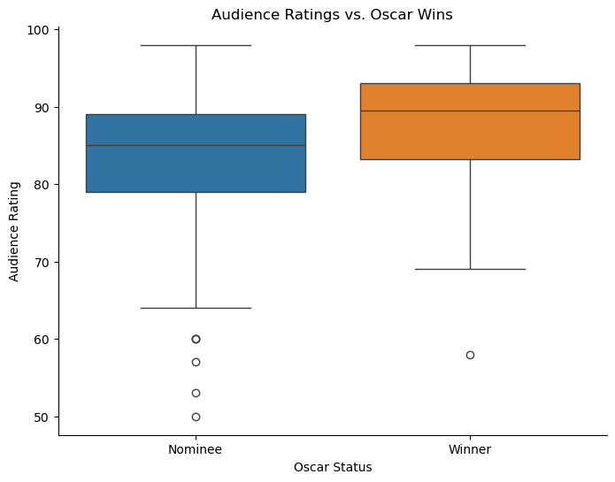

```python
# Created the box plot of audience rating by award status with hue
plt.figure(figsize=(8, 6))
sns.boxplot(x='award', y='audience_rating', data=oscar_table, hue='award')

# Setting labels and title
plt.title('Audience Ratings vs. Oscar Wins')
plt.xlabel('Oscar Status')
plt.ylabel('Audience Rating')


sns.despine()

# Displaying the plot
plt.show()
```

**IMDB Votes vs. Oscar Wins**

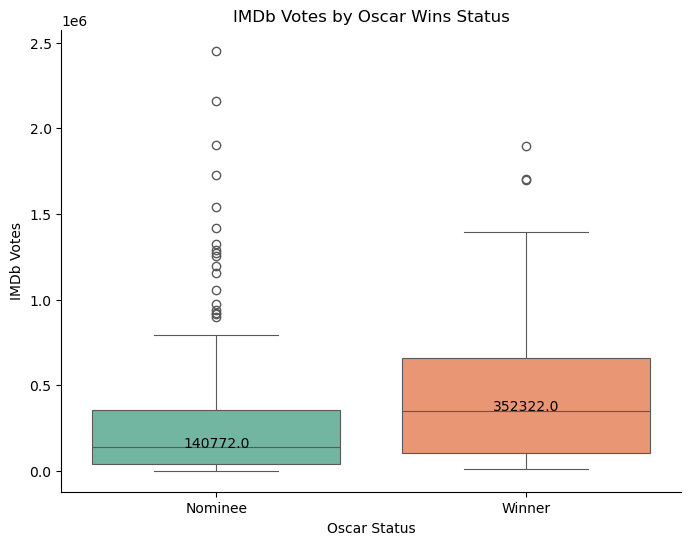

```python
# Created the box plot of IMDb votes by award status
plt.figure(figsize=(8, 6))
sns.boxplot(x='award', y='imdb_votes', data=oscar_table, palette='Set2', linewidth=0.8)

# Added median values as text
medians = oscar_table.groupby('award')['imdb_votes'].median().reset_index()
for i in range(len(medians)):
    plt.text(i, medians['imdb_votes'][i] + 0.5, round(medians['imdb_votes'][i], 0),
             horizontalalignment='center', color='black')

# Setting labels and title
plt.title('IMDb Votes by Oscar Wins Status')
plt.xlabel('Oscar Status')
plt.ylabel('IMDb Votes')

sns.despine()

# Displaying the plot
plt.show()
```